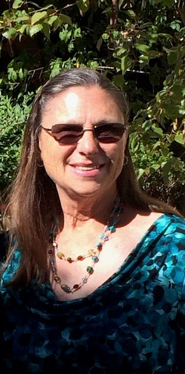

# Dianne Grace Hunt

Dianne was born February 12, 1953, In Redwood City, CA to David and Evelyn Hunt; she noted numerous times that she grew up in a “Leave it to Beaver” family, dad had his own business as a public accountant and Mom was a stay-at-home mom teaching her children many wonderful skills and abilities; both parents preceded Dianne in death.

Dianne lived most of her life in the Redwood City area attending John Gill Elementary School (Miss Sanders remained her favorite teacher), McKinley Junior High School, and graduating from Sequoia High School in 1971. Dianne worked a day job while putting herself through Canada College night classes earning an AA degree and Secretarial Certificate. In 1994, Dianne completed the Mid-Peninsula Open Space docent training and in 1996 with Edgewood Preserve in Redwood City where she served as the Docent Coordinator, creating their docent training binders and setting up trainings. In 1997-1998, Dianne received the Friends Award for her dedication to Edgewood, an award given to those who have provided outstanding service. “The Best Darn Thing that Ever Happened to the Friends of Edgewood” was awarded to her in 2012 after 17 years of dedicated service (1996-2012). Dianne lived and worked away from her hometown for a while in Oregon and Colorado; in 1994, she returned to Redwood City to care for her aging parents and went to work in the textbook center at Los Altos High School until her retirement in 2012. In 2008, Dianne was diagnosed with lymphoma/breast cancer; during her chemo/radiation treatments Dianne met others with this disease and a friendship they called “The Radiant Ladies” was born. On July 17, 2019, Dianne celebrated “My 10-year-cancer-free anniversary” with one of her Radiant Lady friends. In 2012, Dianne moved into the Altamont Senior Apartments in Rohnert Park, sold her car, and became a hike organizer with the local hiking group ‘SWAG’ and, of course, new friendships developed. Dianne enjoyed riding the local SMART train, catching a bus into the ‘city’ and hiking The Presidio; she enjoyed the many local Federal, State, and Regional parks hiking just about every trail, stopping for lunch at precisely her lunch time having perfectly calculated the hike so as to be near a picnic table or large rock when hunger struck. Her knowledge of ‘native’ flowers was incredible and if you spent any time at all hiking (flower hunting) with Dianne you came away knowing several new species as she would suddenly quiz you for names along the way. Dianne had many diverse talents, one of which was playing the Clarinet and participating in her high school Marching Band and Orchestra, also performing in the Summer Drama Music Workshop. Dianne was a Brownie leader following in the footsteps of her mother who had been her Girl Scout leader as a child. Dianne enjoyed sewing and quilting making very interesting quilts from tee shirts she had collected through the years of attending concerts (artists such as David Bowie, Neil Young, Etta James, Jerry Garcia, Rod Stewart, Bob Seger, Eric Clapton, Santana, ZZ Top, Sting, BB King, Tracy Chapman, and Cher to name a few—Dianne was a true 60’s girl); working and volunteering in parks; and thousands of miles traveled with friends or more often, by herself—in 2002, Route 66: Santa Monica, CA to Chicago, IL; in 2004, Part I & 2005 Part II Yellowstone Trail: Washington state to Massachusetts; in 2005, The Sturges Motorcycle Rally: S. Dakota (all together logging 29,793+ miles).

Dianne was a pet/house sitter for several years journaling information regarding the people, their home, pay dates, the name and breed of every pet she cared for along with their pictures. Dianne was a gifted scrapbooker creating many wonderful scrapbooks of her life, interesting cities, historic sites, museums, anything unusual and the friends she made as an avid hiker and traveler. Dianne never forgot anyone and was usually the one to ‘keep in touch’. If you had the pleasure of knowing Dianne you were her lifelong friend and richly blessed by her energy, enthusiasm, thoughtfulness, friendliness, cheerful nature, and you are somewhere in her many memory books or files of most memorable places/people she encountered in her 68 & 1⁄2 years.